# BKMR model for adiposity

Sheena Martenies

4/16/2020

This document summarizes the prelimiary results of the Bayesian Kernel Machine Regression (BKMR) model for adiposity.

For this analysis, we take a subset of those predictors (as selected using the NPB model) and fit a BKMR model to assess independent and joint effects of the exposures. When implementing the NPB model, We used a (conservative) PIP of 0.4 determine which exposures would carry over to the BKMR model. See 07_NPB_Model_AD_MD for more details.

Read in the dataset and select the exposures and covariates

Read in the dataset and select the exposures and covariates

```r
#' =============================================================================
#' Project: ECHO Aim 1 CEI BKMR Anayysis
#' Author: Sheena Martenies
#' Contact: Sheena.Martenies@colostate.edu
#'
#' This project is a follow up the the CEI paper (Env Epi, 2018). Here we're
#' using BKMR to identify which exposures are driving the associations reported
#' in that original paper
#'
#' Date Created: October 21, 2019
#'
#' Description: Using Jennifer Bobb's package to run the BKMR
#' =============================================================================

#' Read in the clean dataset
hs_data <- read_csv(here::here("Data", "HS_Clean_Data.csv"))
nrow(hs_data)
```

```
## [1] 1410
```

```r
hs_data2 <- filter(hs_data, include == 1) %>%
  select(
    #' Exposures
         mean_pm, mean_o3, pct_tree_cover, pct_impervious,
         mean_aadt_intensity, dist_m_tri:dist_m_mine_well,
         cvd_rate_adj, res_rate_adj, violent_crime_rate, property_crime_rate,
         pct_less_hs, pct_unemp, pct_limited_eng, pct_hh_pov,

    #' Covariates
         latina_re, black_re, other_re,
         ed_no_hs, ed_hs, ed_aa, ed_4yr,
         low_bmi, ovwt_bmi, obese_bmi,
         maternal_age, any_smoker, smokeSH, mean_cpss, mean_epsd,
         male, gest_age_w, days_to_peapod,

    #' Outcome
         adiposity) %>%
  na.omit()
nrow(hs_data2)
```

```
## [1] 780
```

We used the exposures selected by the NPB model to fit the BKMR model. Our cutpoint for inclusion in this model was a PIP > 0.4. Note: the adiposity model includes days to peapod as a covariate

```r
#' -----------------------------------------------------------------------------
#' Bayesian Kernel Machine Regression: Birth weight
#' Use just the variables selected by the NPB model (PIP > .25)
#' -----------------------------------------------------------------------------

#' Which variables should we consider?
load(here::here("Results", "NPB_Models_AD.rdata"))
exp_names
```

```
##  [1] "mean_pm"             "mean_o3"             "pct_impervious"
##  [4] "dist_m_mine_well"    "cvd_rate_adj"        "res_rate_adj"
##  [7] "property_crime_rate" "pct_less_hs"         "pct_unemp"
## [10] "pct_hh_pov"
```

```r
hs_data3 <- select(hs_data2, exp_names,
              #' Covariates
                  latina_re, black_re, other_re,
                  ed_no_hs, ed_hs, ed_aa, ed_4yr,
                  low_bmi, ovwt_bmi, obese_bmi,
                  maternal_age, any_smoker, smokeSH, mean_cpss, mean_epsd,
                  male, gest_age_w, days_to_peapod,

              #' Outcome
                  adiposity)
names(hs_data3)
```

```
##  [1] "mean_pm"             "mean_o3"             "pct_impervious"
##  [4] "dist_m_mine_well"    "cvd_rate_adj"        "res_rate_adj"
##  [7] "property_crime_rate" "pct_less_hs"         "pct_unemp"
## [10] "pct_hh_pov"          "latina_re"           "black_re"
## [13] "other_re"            "ed_no_hs"            "ed_hs"
## [16] "ed_aa"               "ed_4yr"              "low_bmi"
## [19] "ovwt_bmi"            "obese_bmi"           "maternal_age"
## [22] "any_smoker"          "smokeSH"             "mean_cpss"
## [25] "mean_epsd"           "male"                "gest_age_w"
## [28] "days_to_peapod"      "adiposity"
```

```r
ncol(hs_data2)
```

```
## [1] 38
```

```r
ncol(hs_data3)
```

```
## [1] 29
```

```r
y <- hs_data3$adiposity
Z <- as.matrix(select(hs_data3, exp_names))
X <- as.matrix(select(hs_data3, latina_re, black_re, other_re,
                      ed_no_hs, ed_hs, ed_aa, ed_4yr,
                      low_bmi, ovwt_bmi, obese_bmi,
                      maternal_age, any_smoker, smokeSH, mean_cpss, mean_epsd,
                      male, gest_age_w, days_to_peapod))

#' Scale these variables
y.scaled <- scale(y)
Z.scaled <- apply(Z, 2, scale)

X.s <- apply(X[,c(11, 14, 15, 17, 18)], 2, scale) #' just the continuous ones

X.scaled <- cbind(X[,1:10], X.s[,1],
                  X[,12:13], X.s[,2:3],
                  X[,16], X.s[,4:5])
colnames(X.scaled)
```

```
##  [1] "latina_re"      "black_re"       "other_re"       "ed_no_hs"
##  [5] "ed_hs"          "ed_aa"          "ed_4yr"         "low_bmi"
##  [9] "ovwt_bmi"       "obese_bmi"      ""               "any_smoker"
## [13] "smokeSH"        "mean_cpss"      "mean_epsd"      ""
## [17] "gest_age_w"     "days_to_peapod"
```

```r
colnames(X.scaled)[c(11,16)] <- c("maternal_age", "male")
```

```r
var(Z.scaled)
```

```
##                          mean_pm      mean_o3 pct_impervious
## mean_pm              1.000000000 -0.003252556     0.04491412
## mean_o3             -0.003252556  1.000000000    -0.02551610
## pct_impervious       0.044914121 -0.025516099     1.00000000
## dist_m_mine_well    -0.263536583 -0.079672044     0.03848024
## cvd_rate_adj         0.132616005  0.029888236     0.39037390
## res_rate_adj         0.094672580  0.014319244     0.40975731
## property_crime_rate  0.080402522 -0.018858645     0.21252691
## pct_less_hs          0.144325222  0.048394870     0.34838683
## pct_unemp            0.017796906  0.034058516     0.38730765
## pct_hh_pov           0.087823617  0.007426438     0.56585263
##                     dist_m_mine_well cvd_rate_adj res_rate_adj
## mean_pm                  -0.26353658   0.13261601   0.09467258
## mean_o3                  -0.07967204   0.02988824   0.01431924
## pct_impervious            0.03848024   0.39037390   0.40975731
## dist_m_mine_well          1.00000000  -0.39546556  -0.21234806
## cvd_rate_adj             -0.39546556   1.00000000   0.86634271
## res_rate_adj             -0.21234806   0.86634271   1.00000000
## property_crime_rate      -0.06345950   0.20654495   0.25558834
## pct_less_hs              -0.36575582   0.57383181   0.47241713
## pct_unemp                -0.24954857   0.46508423   0.45256051
## pct_hh_pov               -0.19920768   0.53237076   0.55887015
##                     property_crime_rate pct_less_hs   pct_unemp
## mean_pm                      0.08040252  0.14432522  0.01779691
## mean_o3                     -0.01885865  0.04839487  0.03405852
## pct_impervious               0.21252691  0.34838683  0.38730765
## dist_m_mine_well            -0.06345950 -0.36575582 -0.24954857
## cvd_rate_adj                 0.20654495  0.57383181  0.46508423
## res_rate_adj                 0.25558834  0.47241713  0.45256051
## property_crime_rate          1.00000000  0.00689379  0.01782784
## pct_less_hs                  0.00689379  1.00000000  0.63292450
## pct_unemp                    0.01782784  0.63292450  1.00000000
## pct_hh_pov                   0.16855235  0.72653072  0.68812727
##                       pct_hh_pov
## mean_pm              0.087823617
## mean_o3              0.007426438
## pct_impervious       0.565852631
## dist_m_mine_well    -0.199207679
## cvd_rate_adj         0.532370759
## res_rate_adj         0.558870145
## property_crime_rate  0.168552353
## pct_less_hs          0.726530718
## pct_unemp            0.688127265
## pct_hh_pov           1.000000000
```

```r
var(X.scaled)
```

```
##                     latina_re      black_re      other_re     ed_no_hs
## latina_re       0.19399460189 -0.0435222672 -0.0175438596  0.037819690
## black_re       -0.04352226721  0.1382097363 -0.0110397946  0.014318159
## other_re       -0.01754385965 -0.0110397946  0.0623020967 -0.002567394
## ed_no_hs        0.03781968994  0.0143181594 -0.0025673941  0.130344623
## ed_hs           0.03262729996  0.0158536585  0.0031664527 -0.028241335
## ed_aa           0.01250781739  0.0178335144  0.0041934104 -0.034758566
## ed_4yr         -0.03620683980 -0.0172607880 -0.0031664527 -0.033968599
## low_bmi        -0.00167868075  0.0026068925 -0.0007702182 -0.003456107
## ovwt_bmi        0.02488397354  0.0003357362 -0.0059050064  0.004641059
## obese_bmi       0.02283499556  0.0073121359  0.0023106547  0.005727264
## maternal_age   -0.11130236864 -0.0914960717 -0.0135406562 -0.147331145
## any_smoker     -0.00753760574  0.0150883776 -0.0006846384  0.017379283
## smokeSH        -0.00349725157  0.0321961094  0.0065896448  0.032487410
## mean_cpss      -0.04032749691 -0.0362044396  0.0225734779 -0.057435615
## mean_epsd       0.03908431534  0.0160927464  0.0210839610  0.071535296
## male            0.00152233304 -0.0055544584  0.0021394951 -0.015108127
## gest_age_w     -0.00772944439 -0.0459673981 -0.0051550835 -0.012119005
## days_to_peapod -0.00006310256  0.0353079864  0.0037188443  0.006899213
##                        ed_hs        ed_aa        ed_4yr       low_bmi
## latina_re       0.0326273000  0.012507817 -0.0362068398 -0.0016786808
## black_re        0.0158536585  0.017833514 -0.0172607880  0.0026068925
## other_re        0.0031664527  0.004193410 -0.0031664527 -0.0007702182
## ed_no_hs       -0.0282413350 -0.034758566 -0.0339685988 -0.0034561074
## ed_hs           0.1499144202 -0.041420625 -0.0404792469 -0.0005134788
## ed_aa          -0.0414206247  0.174951450 -0.0498206116  0.0046015602
## ed_4yr         -0.0404792469 -0.049820612  0.1721075672 -0.0003752345
## low_bmi        -0.0005134788  0.004601560 -0.0003752345  0.0298607682
## ovwt_bmi       -0.0069319641  0.017932260  0.0013034462 -0.0080576676
## obese_bmi       0.0268934531  0.012165498 -0.0137849314 -0.0060432507
## maternal_age   -0.1061266380 -0.034152305  0.1077776102 -0.0091971230
## any_smoker      0.0045357296  0.008544814 -0.0153977815  0.0011652019
## smokeSH         0.0251818571  0.021118462 -0.0353773740  0.0026463908
## mean_cpss      -0.0356451617  0.029189204  0.0275174804  0.0079977462
## mean_epsd       0.0221439428  0.016391602 -0.0481925954  0.0107834260
## male            0.0007488233  0.001119121  0.0062868240 -0.0001974919
## gest_age_w     -0.0148312028 -0.025824190  0.0330362179 -0.0033335217
## days_to_peapod  0.0014765999  0.025249438 -0.0107106080 -0.0073703791
##                     ovwt_bmi    obese_bmi maternal_age    any_smoker
## latina_re       0.0248839735  0.022834996 -0.111302369 -0.0075376057
```

[output cut: 40 more lines]

```
## ed_no_hs       -0.012119005  0.00689921335
## ed_hs          -0.014831203  0.00147659993
## ed_aa          -0.025824190  0.02524943813
## ed_4yr          0.033036218 -0.01071060804
## low_bmi        -0.003333522 -0.00737037914
## ovwt_bmi       -0.015929653 -0.01397511387
## obese_bmi      -0.018839063  0.00387449725
## maternal_age    0.073088144 -0.00159199026
## any_smoker     -0.029706937 -0.00228851955
## smokeSH        -0.050997369  0.01073164223
## mean_cpss      -0.007275391 -0.00599542077
## mean_epsd      -0.086750438  0.01124930187
## male           -0.039081937  0.03073094727
## gest_age_w      1.000000000 -0.13525838557
## days_to_peapod -0.135258386  1.00000000000
```

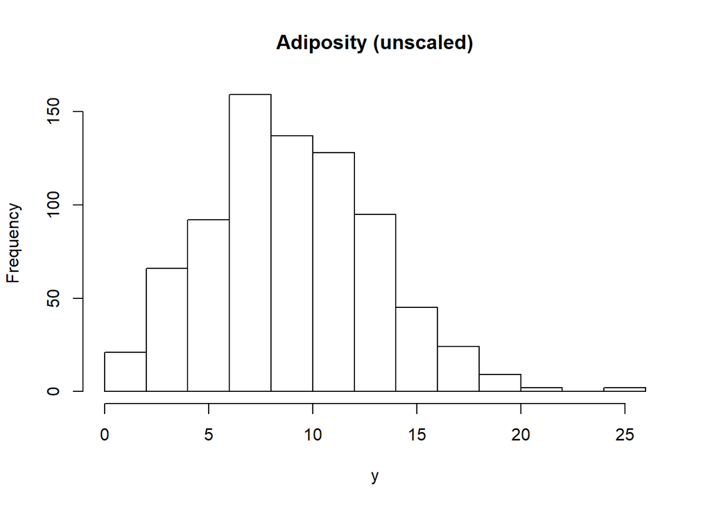

```r
hist(y, main = "Adiposity (unscaled)")
```

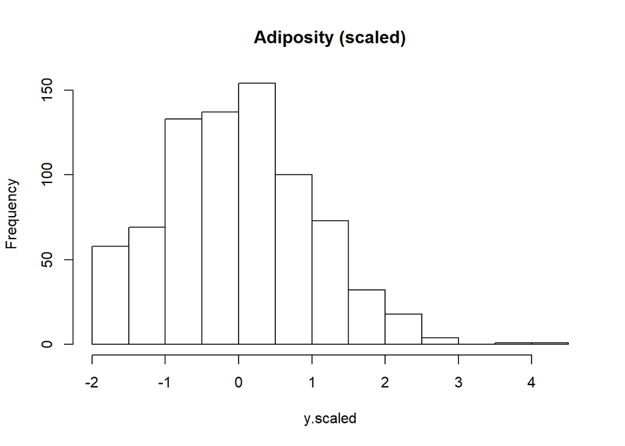

```r
hist(y.scaled, main = "Adiposity (scaled)")
```

Fitting the BKMR model and investigating model convergence

```
## Fitted object of class 'bkmrfit'
## Iterations: 10000
## Outcome family: gaussian
## Model fit on: 2020-04-15 15:46:52
```

```
##  [1] "h.hat"           "beta"            "lambda"
##  [4] "sigsq.eps"       "r"               "acc.r"
##  [7] "acc.lambda"      "delta"           "acc.rdelta"
## [10] "move.type"       "est.h"           "time1"
## [13] "time2"           "iter"            "family"
## [16] "starting.values" "control.params"  "X"
## [19] "Z"               "y"               "ztest"
## [22] "data.comps"      "varsel"
```

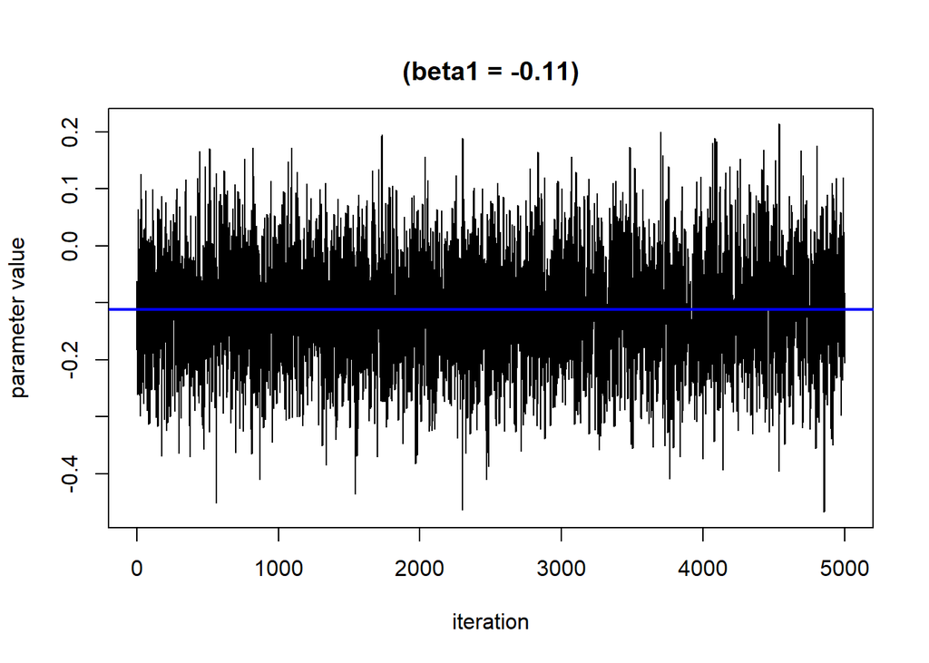

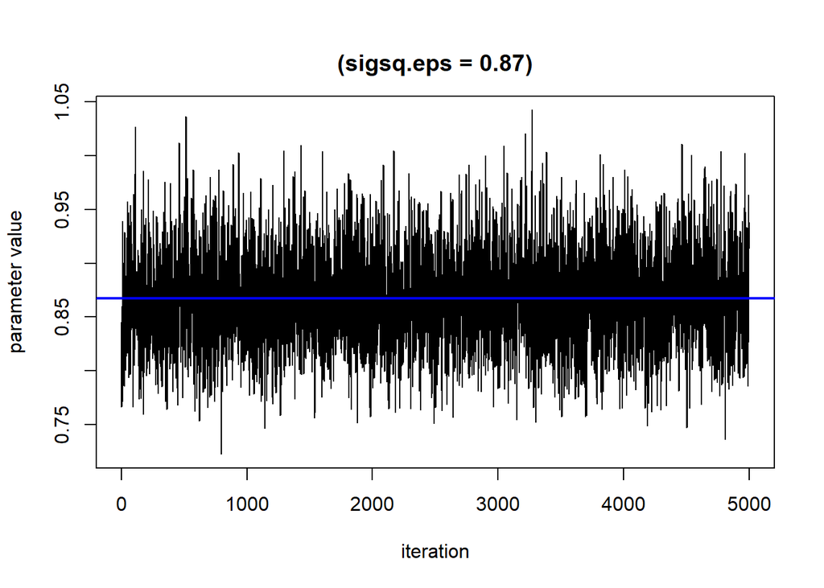

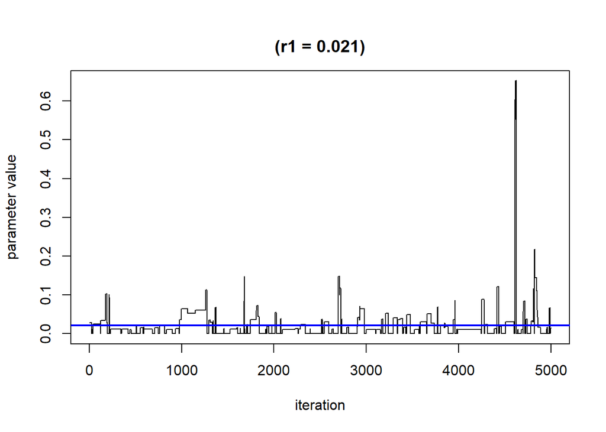

What do the posterior inclusion probabilities (PIPs) look like?

```
##               variable    PIP
## 1  property_crime_rate 0.7916
## 2         cvd_rate_adj 0.6986
## 3           pct_hh_pov 0.6492
## 4         res_rate_adj 0.6490
## 5            pct_unemp 0.6348
## 6              mean_pm 0.6170
## 7     dist_m_mine_well 0.5920
## 8              mean_o3 0.5670
## 9       pct_impervious 0.5396
## 10         pct_less_hs 0.5384
```

How does h(z) compare when using the three different approaches?

```r
h_est_compare
```

```
##   method   post_mean    post_sd
## 1      1 0.014523378 0.04550222
## 2      2 0.007345321 0.09917343
## 3      3 0.009450469 0.09707995
```

Summarize the BKMR model output: Exposure-response curves for each exposure while holding the others at their 25th, 50th, or 75th percentiles

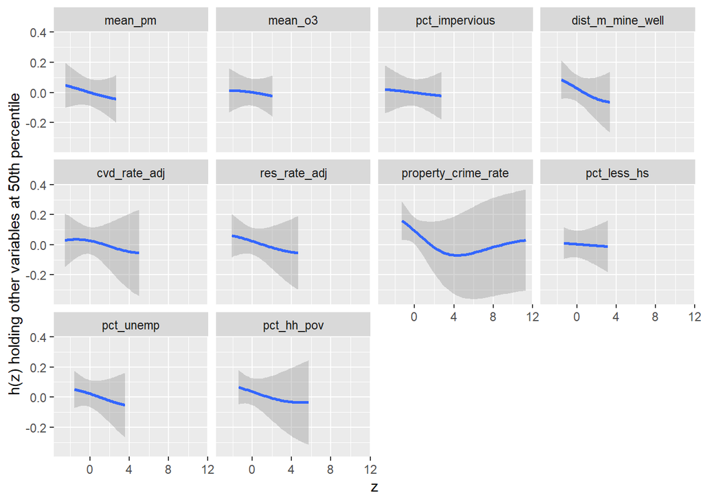

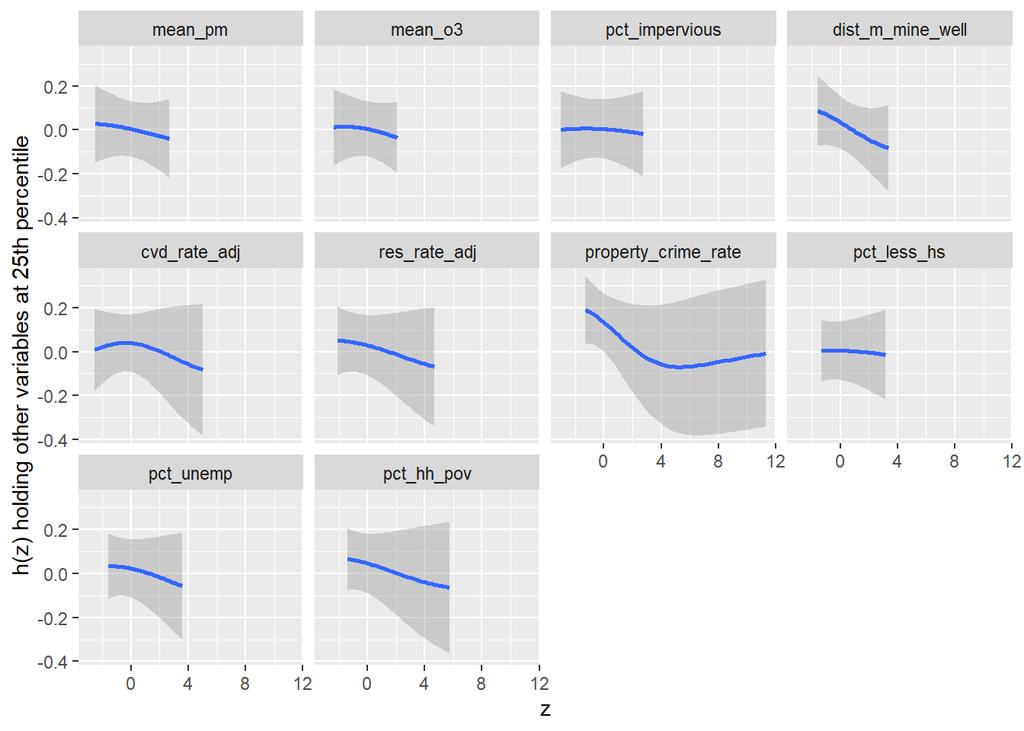

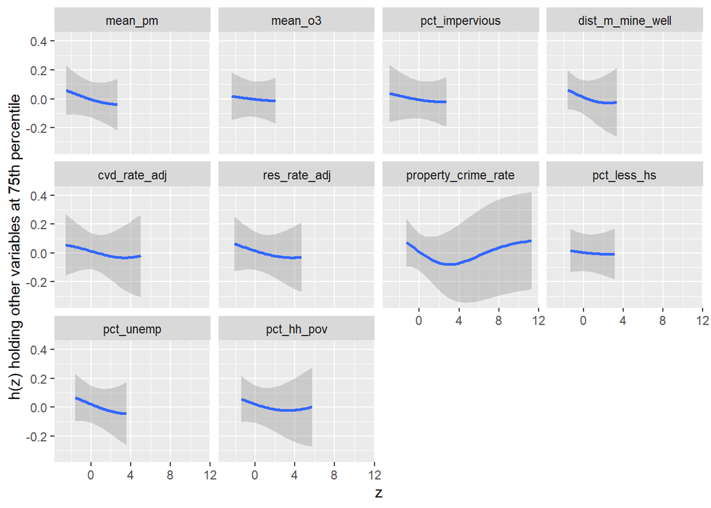

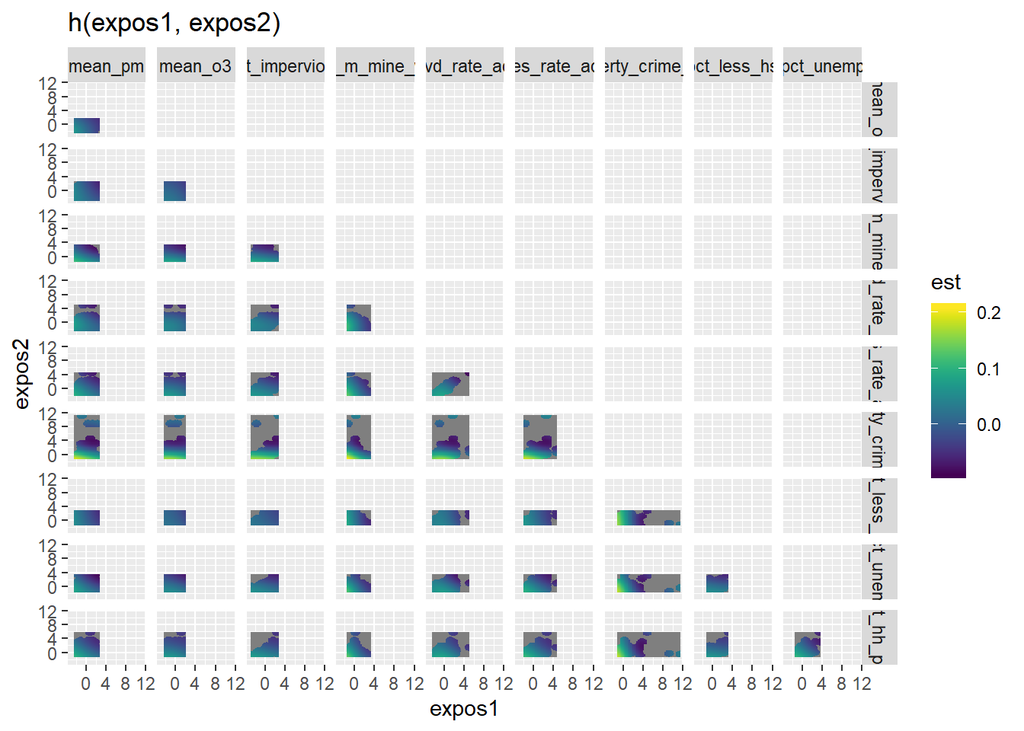

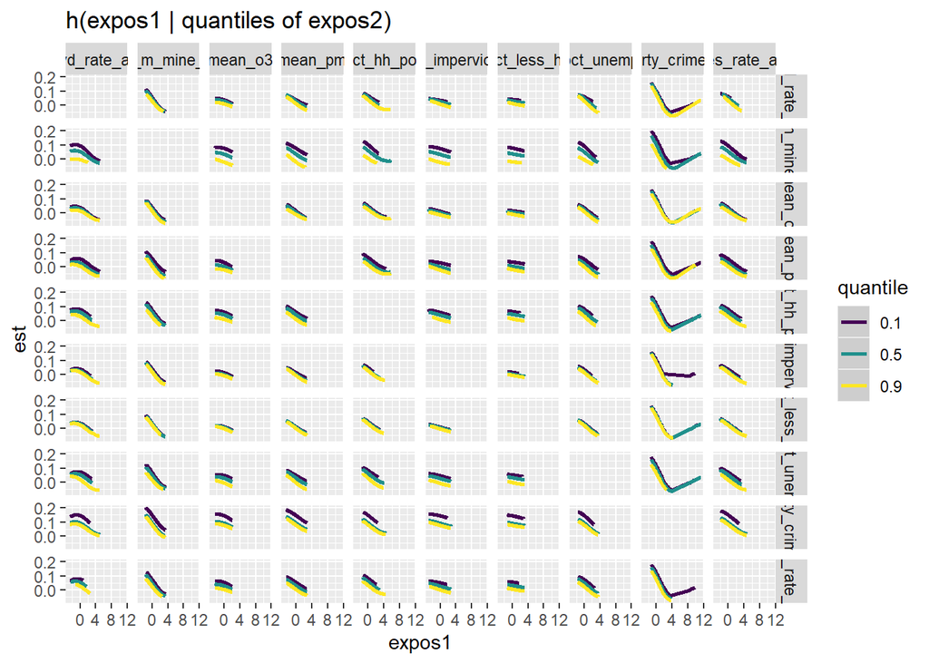

Summarize the BKMR model output: plotting the overall effect size for each percentile relative to the 50th percentile

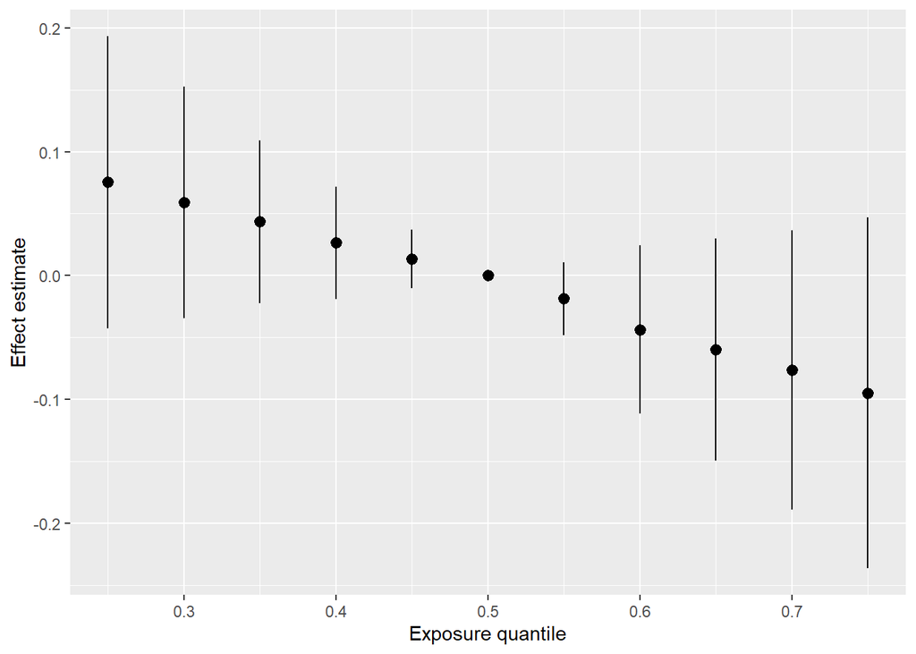

Summarize the BKMR model output: Estimate the risks for the individual variables the exposure is at the 75th percentile relative to the 25th percentile (essentially an IQR increase), holding all other exposures at the 25th, 50th, and 75th percentiles

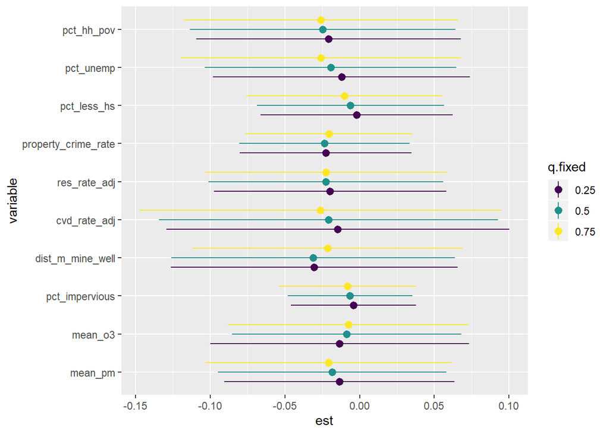

Checking for interation: by how much do the effect sizes for each expsoure change when we increase all the other exposures from the 25th to the 75th percentiles

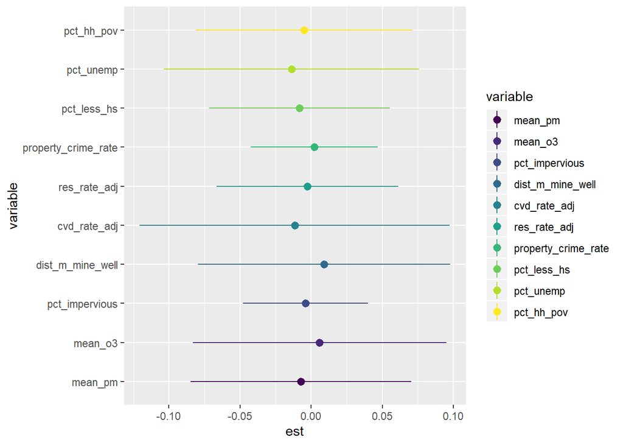